```r
library(vegan)
data(dune)
data(dune.env)
?dune
```

```r
dune_mds = metaMDS(dune)
```

```
## *** Solution reached
```

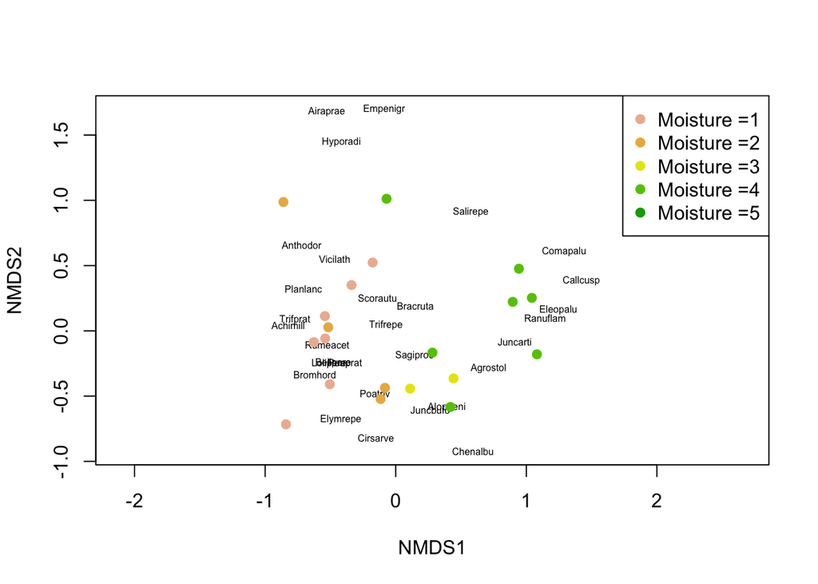

```r
 plot(dune_mds, type='n')
 text(dune_mds, 'sp', cex=.5)
 # generate vector of colors
 color_vect = rev(terrain.colors(6))[-1]
 points(dune_mds, 'sites', pch=19,
        col=color_vect[dune.env$Moisture])
 legend('topright', paste("Moisture =", 1:5, sep=''),
        col=color_vect, pch=19)
```

1. The goal of the above graph is to get an overall image of the similarity (and dissimilarity) between the samples and the species. The plot suggests that there is aggrgation of different mositures and they correspond to different species that are present. We need to examine these apparent patterns quantitatively to know confidently that the observed differences are significant.

```r
dune.env$Moisture = factor(dune.env$Moisture, levels = 1:5, ordered = FALSE)
```

```r
cca_dune = cca(dune ~ ., data=dune.env)
RsquareAdj(cca_dune, 100)
```

```
## $r.squared
## [1] 0.7106267
##
## $adj.r.squared
## [1] 0.2351642
```

adjusted r squared is much lower…a lot of variation may be due to random chance.

```r
anova(cca_dune, permutations = 999)
```

```
## Permutation test for cca under reduced model
## Permutation: free
## Number of permutations: 999
##
## Model: cca(formula = dune ~ A1 + Moisture + Management + Use + Manure, data = dune.env)
##          Df ChiSquare      F Pr(>F)
## Model    12    1.5032 1.4325  0.038 *
## Residual  7    0.6121
## ---
## Signif. codes:  0 '***' 0.001 '**' 0.01 '*' 0.05 '.' 0.1 ' ' 1
```

```r
anova(cca_dune, permutations = 999, by="margin")
```

```
## Permutation test for cca under reduced model
## Marginal effects of terms
## Permutation: free
## Number of permutations: 999
##
## Model: cca(formula = dune ~ A1 + Moisture + Management + Use + Manure, data = dune.env)
##            Df ChiSquare      F Pr(>F)
## A1          1   0.11070 1.2660  0.224
## Moisture    3   0.31587 1.2041  0.236
## Management  2   0.15882 0.9081  0.555
## Use         2   0.13010 0.7439  0.775
## Manure      3   0.25490 0.9717  0.497
## Residual    7   0.61210
```

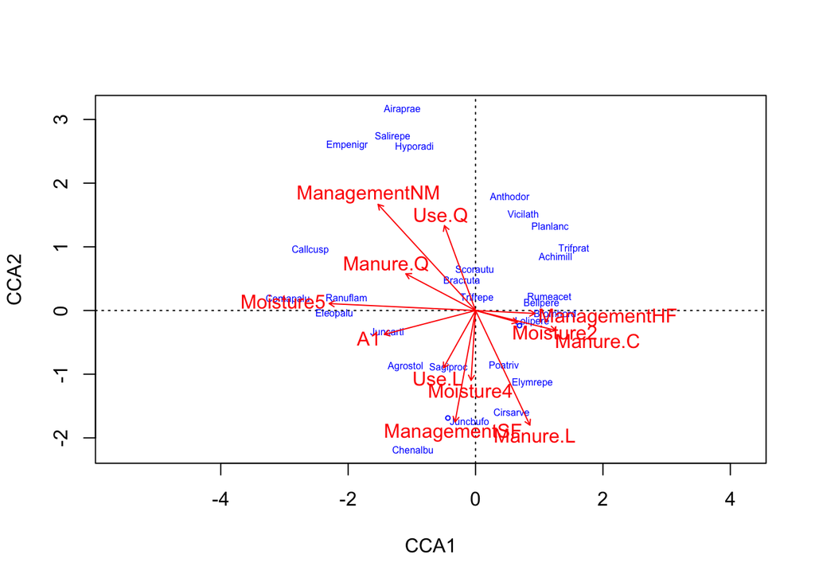

```r
plot(cca_dune, type='n', scaling=1)
orditorp(cca_dune, display='sp', cex=0.5, scaling=1, col='blue')
text(cca_dune, display='bp', col='red')
```

2. The overall model does not exaplin much variation. None of the variables are significant when they stand alone. Next I will examine individuals variables that are slightly more significant then the others…

```r
cca_dune1 = cca(dune ~ A1 + Moisture + Management + Manure, data=dune.env)
RsquareAdj(cca_dune1, 100)
```

```
## $r.squared
## [1] 0.6491209
##
## $adj.r.squared
## [1] 0.2643215
```

```r
anova(cca_dune1, permutations = 999)
```

```
## Permutation test for cca under reduced model
## Permutation: free
## Number of permutations: 999
##
## Model: cca(formula = dune ~ A1 + Moisture + Management + Manure, data = dune.env)
##          Df ChiSquare     F Pr(>F)
## Model    10    1.3731 1.665  0.005 **
## Residual  9    0.7422
## ---
## Signif. codes:  0 '***' 0.001 '**' 0.01 '*' 0.05 '.' 0.1 ' ' 1
```

```r
anova(cca_dune1, permutations = 999, by="margin")
```

```
## Permutation test for cca under reduced model
## Marginal effects of terms
## Permutation: free
## Number of permutations: 999
##
## Model: cca(formula = dune ~ A1 + Moisture + Management + Manure, data = dune.env)
##            Df ChiSquare      F Pr(>F)
## A1          1   0.15168 1.8393  0.057 .
## Moisture    3   0.31960 1.2919  0.168
## Management  2   0.15239 0.9239  0.572
## Manure      3   0.23390 0.9454  0.564
## Residual    9   0.74220
## ---
## Signif. codes:  0 '***' 0.001 '**' 0.01 '*' 0.05 '.' 0.1 ' ' 1
```

drop either manure or management (I dropped manure just because I am more interested in Managment)

```r
cca_dune2 = cca(dune ~ A1 + Moisture + Management, data=dune.env)
RsquareAdj(cca_dune2, 100)
```

```
## $r.squared
## [1] 0.5385459
##
## $adj.r.squared
## [1] 0.2693799
```

```r
anova(cca_dune2, permutations = 999)
```

```
## Permutation test for cca under reduced model
## Permutation: free
## Number of permutations: 999
##
## Model: cca(formula = dune ~ A1 + Moisture + Management, data = dune.env)
##          Df ChiSquare      F Pr(>F)
## Model     7    1.1392 2.0007  0.001 ***
## Residual 12    0.9761
## ---
## Signif. codes:  0 '***' 0.001 '**' 0.01 '*' 0.05 '.' 0.1 ' ' 1
```

```r
anova(cca_dune2, permutations = 999, by='margin')
```

```
## Permutation test for cca under reduced model
## Marginal effects of terms
## Permutation: free
## Number of permutations: 999
##
## Model: cca(formula = dune ~ A1 + Moisture + Management, data = dune.env)
##            Df ChiSquare      F Pr(>F)
## A1          1   0.13679 1.6817  0.084 .
## Moisture    3   0.35939 1.4728  0.073 .
## Management  3   0.39543 1.6205  0.026 *
## Residual   12   0.97610
## ---
## Signif. codes:  0 '***' 0.001 '**' 0.01 '*' 0.05 '.' 0.1 ' ' 1
```

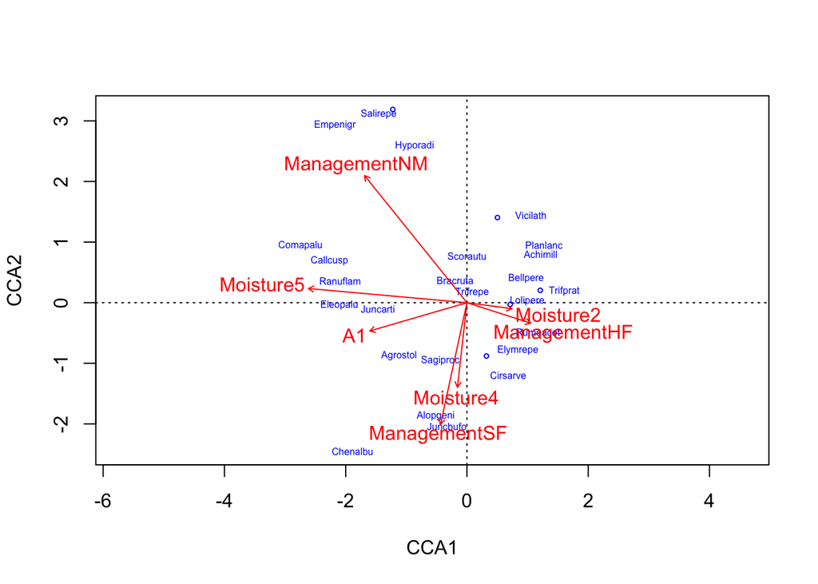

```r
plot(cca_dune2, type='n', scaling=1)
orditorp(cca_dune2, display='sp', cex=0.5, scaling=1, col='blue')
text(cca_dune2, display='bp', col='red')
```

```r
cca_dune_mm = cca(dune ~ Moisture + Management, data=dune.env)
RsquareAdj(cca_dune_mm, 100)
```

```
## $r.squared
## [1] 0.4738772
##
## $adj.r.squared
## [1] 0.2302189
```

```r
anova(cca_dune_mm, permutations = 999)
```

```
## Permutation test for cca under reduced model
## Permutation: free
## Number of permutations: 999
##
## Model: cca(formula = dune ~ Moisture + Management, data = dune.env)
##          Df ChiSquare      F Pr(>F)
## Model     6    1.0024 1.9515  0.001 ***
## Residual 13    1.1129
## ---
## Signif. codes:  0 '***' 0.001 '**' 0.01 '*' 0.05 '.' 0.1 ' ' 1
```

```r
anova(cca_dune_mm, permutations = 999, by='margin')
```

```
## Permutation test for cca under reduced model
## Marginal effects of terms
## Permutation: free
## Number of permutations: 999
##
## Model: cca(formula = dune ~ Moisture + Management, data = dune.env)
##            Df ChiSquare      F Pr(>F)
## Moisture    3   0.39854 1.5518  0.037 *
## Management  3   0.37407 1.4565  0.064 .
## Residual   13   1.11289
## ---
## Signif. codes:  0 '***' 0.001 '**' 0.01 '*' 0.05 '.' 0.1 ' ' 1
```

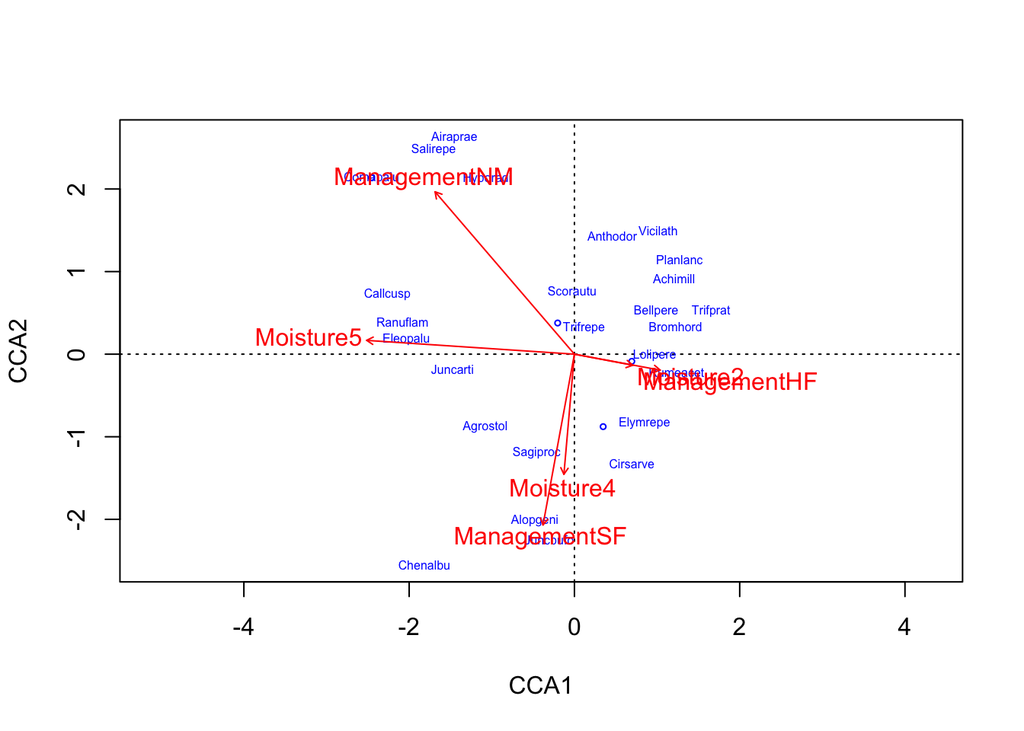

```r
plot(cca_dune_mm, type='n', scaling=1)
orditorp(cca_dune_mm, display='sp', cex=0.5, scaling=1, col='blue')
text(cca_dune_mm, display='bp', col='red')
```

Only moisture is significant alone…now I will do both individually

```r
cca_dune3 = cca(dune ~ Management, data=dune.env)
RsquareAdj(cca_dune3, 100)
```

```
## $r.squared
## [1] 0.285467
##
## $adj.r.squared
## [1] 0.1517011
```

```r
anova(cca_dune3, permutations = 999, by='margin')
```

```
## Permutation test for cca under NA model
## Marginal effects of terms
## Permutation: free
## Number of permutations: 999
##
## Model: cca(formula = dune ~ Management, data = dune.env)
##            Df ChiSquare      F Pr(>F)
## Management  3   0.60384 2.1307  0.001 ***
## Residual   16   1.51143
## ---
## Signif. codes:  0 '***' 0.001 '**' 0.01 '*' 0.05 '.' 0.1 ' ' 1
```

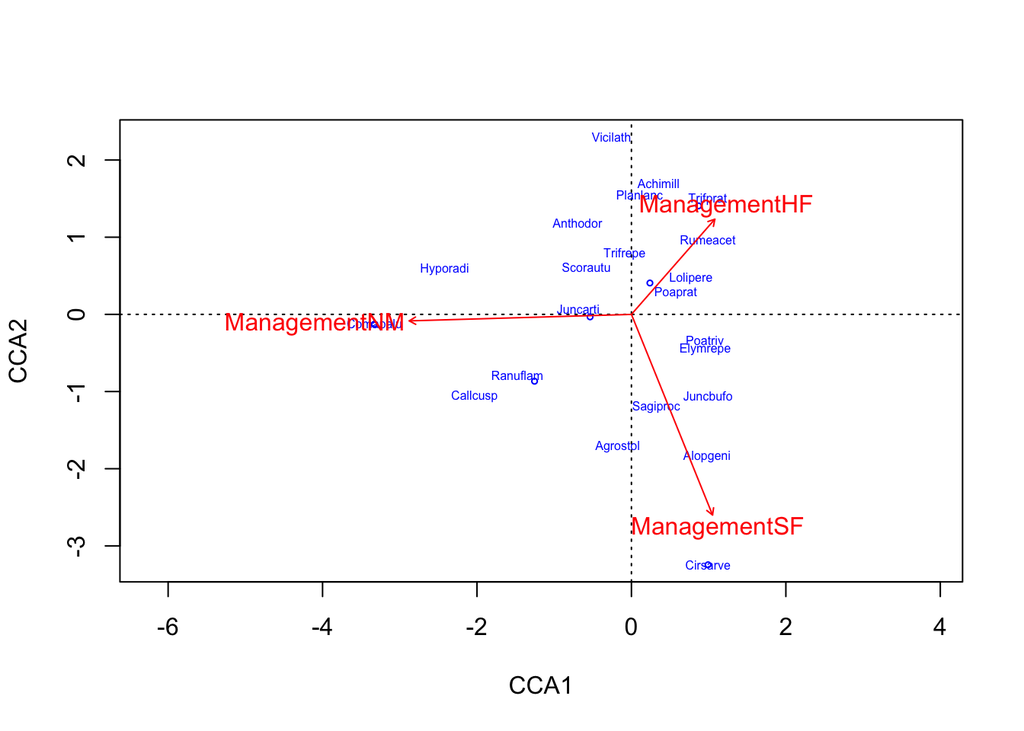

```r
plot(cca_dune3, type='n', scaling=1)
orditorp(cca_dune3, display='sp', cex=0.5, scaling=1, col='blue')
text(cca_dune3, display='bp', col='red')
```

I want to look at moisture alone as well…

```r
cca_dune4 = cca(dune ~ Moisture, data=dune.env)
RsquareAdj(cca_dune4, 100)
```

```
## $r.squared
## [1] 0.2970359
##
## $adj.r.squared
## [1] 0.1661562
```

```r
anova(cca_dune4, permutations = 999, by='margin')
```

```
## Permutation test for cca under NA model
## Marginal effects of terms
## Permutation: free
## Number of permutations: 999
##
## Model: cca(formula = dune ~ Moisture, data = dune.env)
##          Df ChiSquare      F Pr(>F)
## Moisture  3   0.62831 2.2536  0.001 ***
## Residual 16   1.48695
## ---
## Signif. codes:  0 '***' 0.001 '**' 0.01 '*' 0.05 '.' 0.1 ' ' 1
```

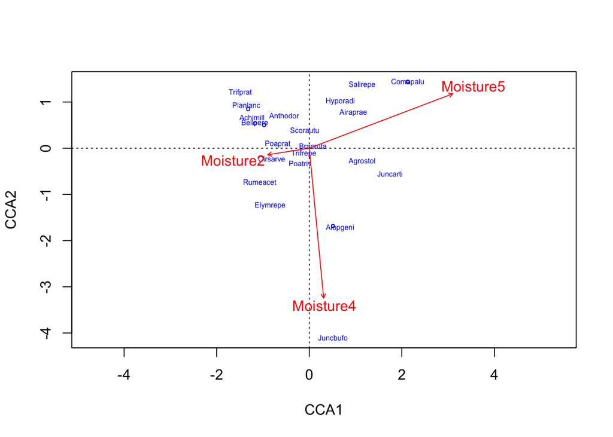

```r
plot(cca_dune4, type='n', scaling=1)
orditorp(cca_dune4, display='sp', cex=0.5, scaling=1, col='blue')
text(cca_dune4, display='bp', col='red')
```

visiualize both models together…

```r
dune_fit = envfit(dune_mds, dune.env)
dune_fit
```

```
##
## ***VECTORS
##
##      NMDS1   NMDS2     r2 Pr(>r)
## A1 0.96473 0.26324 0.3649  0.019 *
## ---
## Signif. codes:  0 '***' 0.001 '**' 0.01 '*' 0.05 '.' 0.1 ' ' 1
## Permutation: free
## Number of permutations: 999
##
## ***FACTORS:
##
## Centroids:
##                NMDS1   NMDS2
## Moisture1    -0.5101 -0.0403
## Moisture2    -0.3938  0.0139
## Moisture4     0.2765 -0.4033
## Moisture5     0.6561  0.1476
## ManagementBF -0.4534 -0.0102
## ManagementHF -0.2636 -0.1282
## ManagementNM  0.2957  0.5790
## ManagementSF  0.1506 -0.4670
## UseHayfield  -0.1568  0.3248
## UseHaypastu  -0.0412 -0.3370
## UsePasture    0.2854  0.0844
## Manure0       0.2957  0.5790
## Manure1      -0.2482 -0.0215
## Manure2      -0.3079 -0.1866
## Manure3       0.3102 -0.2470
## Manure4      -0.3463 -0.5583
##
## Goodness of fit:
##                r2 Pr(>r)
## Moisture   0.5014  0.002 **
## Management 0.4134  0.005 **
## Use        0.1871  0.121
## Manure     0.4247  0.017 *
## ---
## Signif. codes:  0 '***' 0.001 '**' 0.01 '*' 0.05 '.' 0.1 ' ' 1
## Permutation: free
## Number of permutations: 999
```

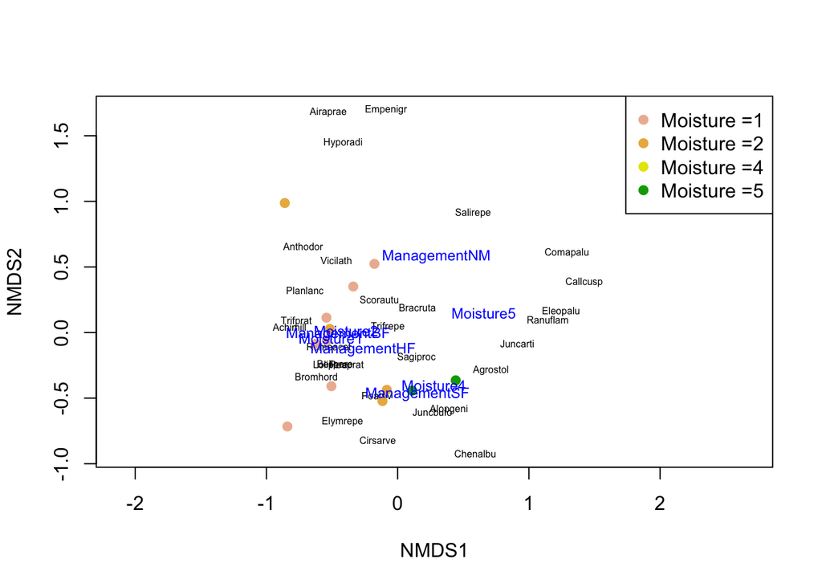

```r
plot(dune_mds, type = 'n')
text(dune_mds, 'sp', cex = 0.5)
##generate vector of colors
mois_lvs = sort(unique(dune.env$Moisture))
color_vect = rev(terrain.colors(length(mois_lvs) + 1))[-1]
points(dune_mds, 'sites', pch = 19,
       col = color_vect[dune.env$Moisture])
##add enviornmental variables for p value less than 0.01
plot(dune_fit, p.max = 0.01, cex = 0.75)
legend('topright', paste("Moisture =", mois_lvs, sep = ''),
       col = color_vect, pch = 19)
```

3. The first approach suggests that moisture may drive some significant differences along the axes. It also shows that species may prefer various moistures and are distributed in a pattern that corresponds to moisture. The CCA model can tell us quantitatively what is going on with the model. From analysis, management and moisture are significantly driving the variation. This information is useful to quantify significance and back up the first visual model. I find both analyses useful, but I think the CCA is necessary to justify the patterns that you see.